# Differential Gene Expression of WT vs delta at 37°C in YPD samples

Edward Wallace

2024-12-04

# Summary

Differential Gene Expression WT vs delta at 37°C in YPD samples, using DESeq2

This analysis produces files:

- `deseq_df_WTvsdelta_37C_YPD.txt`
- `deglist_WTvsdelta_37C_YPD_up2x_FDR5.txt`
- `deglist_WTvsdelta_37C_YPD_down2x_FDR5.txt`

## Load count data from shared script load_count_data.Rmd

# Load and organise count data

`load_count_data.Rmd` is just to load and organise the raw count data in R, as well as loading libraries for data analysis. Other scripts can just run this one instead of duplicating code, especially scripts for differential gene expression analysis.

This runs *after* `QC_PCA.Rmd`, which does the organisation. This just loads the organised counts from the file `results/summaries/counts_bysamplecode.txt`.

## Load the organised counts

```r
counts_all <-
  here::here("results", "summaries", "counts_bysamplecode.txt") %>%
  readr::read_tsv(comment = "#",
                  col_types = "ciiiiiiiiiiiiiiiiiiiiiiiiiiiiiii")   %>%
  magrittr::set_rownames(.$Gene)
counts_all
```

```
## # A tibble: 6,795 × 32
##    Gene       Length WT_30_Y_1 WT_30_Y_2 WT_30_Y_3 FL_30_Y_1 FL_30_Y_2 FL_30_Y_3
##  * <chr>       <int>     <int>     <int>     <int>     <int>     <int>     <int>
##  1 CNAG_00002   1027       322       378       346       310       309       174
##  2 CNAG_00003   2397        19        43        27        54        52        33
##  3 CNAG_00004   3424        94        80        83       102        94        65
##  4 CNAG_00005   2162       462       399       385       378       344       310
##  5 CNAG_00006   1450      1019      1533      1256      1505      1359       778
##  6 CNAG_00007   2294       471       703       579       476       407       284
##  7 CNAG_00008   4351       141       226       206       272       259       164
##  8 CNAG_00009   1794       160       162       187       323       250       171
##  9 CNAG_00010   3879       195       199       242       362       272       159
## 10 CNAG_00011   2037        85       117       114       162       139        81
## # ℹ 6,785 more rows
## # ℹ 24 more variables: WT_37_Y_1 <int>, WT_37_Y_2 <int>, WT_37_Y_3 <int>,
## #   FL_37_Y_1 <int>, FL_37_Y_2 <int>, FL_37_Y_3 <int>, WT_37_C_1 <int>,
## #   WT_37_C_2 <int>, WT_37_C_3 <int>, FL_37_C_1 <int>, FL_37_C_2 <int>,
## #   FL_37_C_3 <int>, WT_37_E_1 <int>, WT_37_E_2 <int>, WT_37_E_3 <int>,
## #   FL_37_E_1 <int>, FL_37_E_2 <int>, FL_37_E_3 <int>, WT_37_CE_1 <int>,
## #   WT_37_CE_2 <int>, WT_37_CE_3 <int>, FL_37_CE_1 <int>, FL_37_CE_2 <int>, …
```

## Load the sample sheet

```r
sample_sheet <-
  here::here("input", "experiment",
             "CryptoRNAseqFLC1SampleKey.csv") %>%
  readr::read_csv(comment = "#", col_types = "ccccccc") %>%
  dplyr::mutate(Condition = stringr::str_sub(SampleName,start = 1L, end = -3L)) %>%
  dplyr::transmute(SampleID = as_factor(SampleID),
                   SampleName = as_factor(SampleName),
                   Condition = as_factor(Condition),
                   FLC1 = factor(FLC1, levels = c("delta", "WT")),
                   Temperature = factor(Temperature, levels = c("30", "37")),
                   Media = as_factor(Media),
                   BioRep = as_factor(BioRep))

sample_sheet
```

```
## # A tibble: 30 × 7
##    SampleID SampleName Condition FLC1  Temperature Media BioRep
##    <fct>    <fct>      <fct>     <fct> <fct>       <fct> <fct>
##  1 1        WT_30_Y_1  WT_30_Y   WT    30          YPD   1
##  2 2        WT_30_Y_2  WT_30_Y   WT    30          YPD   2
##  3 3        WT_30_Y_3  WT_30_Y   WT    30          YPD   3
##  4 4        FL_30_Y_1  FL_30_Y   delta 30          YPD   1
##  5 5        FL_30_Y_2  FL_30_Y   delta 30          YPD   2
##  6 6        FL_30_Y_3  FL_30_Y   delta 30          YPD   3
##  7 7        WT_37_Y_1  WT_37_Y   WT    37          YPD   1
##  8 8        WT_37_Y_2  WT_37_Y   WT    37          YPD   2
##  9 9        WT_37_Y_3  WT_37_Y   WT    37          YPD   3
## 10 10       FL_37_Y_1  FL_37_Y   delta 37          YPD   1
## # ℹ 20 more rows
```

## Load H99 Gene information

```r
gene_info_df <-
  here::here("input", "annotation",
             "H99_geneinfo_FungiDB59.txt") %>%
  readr::read_tsv(comment = "#")  %>%
  dplyr::rename(gene = GeneID, geneName = GeneName)
```

# DESeq on a subset of data, only 37C in YPD

```r
sample_sheet_WTvsdelta_37C_YPD <-
  dplyr::filter(sample_sheet,
                Temperature == "37", Media == "YPD")

dds_WTvsdelta_37C_YPD <-
  DESeqDataSetFromMatrix(
    countData = counts_all %>%
      dplyr::select(sample_sheet_WTvsdelta_37C_YPD$SampleName) %>%
      magrittr::set_rownames(counts_all$Gene),
    colData = sample_sheet_WTvsdelta_37C_YPD,
    design = ~ FLC1) %>%
  DESeq()
dds_WTvsdelta_37C_YPD
```

```
## class: DESeqDataSet
## dim: 6795 6
## metadata(1): version
## assays(4): counts mu H cooks
## rownames(6795): CNAG_00002 CNAG_00003 ... CNAG_14001 CNAG_14002
## rowData names(22): baseMean baseVar ... deviance maxCooks
## colnames(6): WT_37_Y_1 WT_37_Y_2 ... FL_37_Y_2 FL_37_Y_3
## colData names(8): SampleID SampleName ... BioRep sizeFactor
```

```r
results(dds_WTvsdelta_37C_YPD)
```

```
## log2 fold change (MLE): FLC1 WT vs delta
## Wald test p-value: FLC1 WT vs delta
## DataFrame with 6795 rows and 6 columns
##             baseMean log2FoldChange     lfcSE       stat    pvalue      padj
##            <numeric>      <numeric> <numeric>  <numeric> <numeric> <numeric>
## CNAG_00002  445.3210     -0.0131039 0.1320603 -0.0992263 0.9209586  0.941903
## CNAG_00003   49.4729     -0.4829406 0.2730471 -1.7687077 0.0769427  0.128320
## CNAG_00004  107.5711      0.2423738 0.1890020  1.2823875 0.1997068  0.286034
## CNAG_00005  666.9180     -0.0198152 0.1245374 -0.1591104 0.8735819  0.909723
## CNAG_00006 1677.6572      0.1564381 0.0890361  1.7570196 0.0789145  0.131083
## ...              ...            ...       ...        ...       ...       ...
## CNAG_08027 333.77309     -0.3061507  0.132725  -2.306663 0.0210736  0.042386
## CNAG_08028 111.24722     -0.2633673  0.186173  -1.414638 0.1571747  0.234769
## CNAG_08029 107.44692      0.1728125  0.196800   0.878111 0.3798837  0.480572
## CNAG_14001 414.87927     -0.0445938  0.131145  -0.340033 0.7338315  0.799746
## CNAG_14002   1.24495     -1.1303981  1.635258  -0.691266 0.4893985  0.587557
```

```r
resultsNames(dds_WTvsdelta_37C_YPD)
```

```
## [1] "Intercept"        "FLC1_WT_vs_delta"
```

```r
deseq_df_WTvsdelta_37C_YPD <-
  biobroom::tidy.DESeqDataSet(dds_WTvsdelta_37C_YPD) %>%
  dplyr::filter(term == "FLC1_WT_vs_delta") %>%
  dplyr::left_join(gene_info_df,
                   by = "gene") %>%
  dplyr::select(gene,
                geneName,
                baseMean,
                log2FC = estimate,
                stderror,
                padj = p.adjusted)
```

## List DEGs most UP in WT vs delta

We cut off at 2x changes with 5% FDR here.

```r
# Make data frames of DEGs up and down, arranged by log2FC
DEGdf_WT_up2x_FDR5 <-
  dplyr::filter(deseq_df_WTvsdelta_37C_YPD,
                log2FC > 1, padj < 0.05) %>%
  dplyr::arrange(desc(log2FC))
print(DEGdf_WT_up2x_FDR5, n = 20)
```

```
## # A tibble: 40 × 6
##    gene       geneName baseMean log2FC stderror     padj
##    <chr>      <chr>       <dbl>  <dbl>    <dbl>    <dbl>
##  1 CNAG_04283 <NA>        247.    9.77   1.03   7.56e-20
##  2 CNAG_03454 <NA>         65.7   1.94   0.618  4.61e- 3
##  3 CNAG_04469 <NA>         88.6   1.82   0.544  2.50e- 3
##  4 CNAG_07695 <NA>        123.    1.51   0.187  1.28e-14
##  5 CNAG_00987 <NA>        380.    1.39   0.133  8.95e-24
##  6 CNAG_04901 <NA>        250.    1.28   0.173  1.71e-12
##  7 CNAG_05144 CAN2       1327.    1.25   0.109  9.21e-29
##  8 CNAG_00904 <NA>         20.0   1.24   0.413  6.95e- 3
##  9 CNAG_00409 <NA>        200.    1.23   0.170  4.66e-12
## 10 CNAG_06096 <NA>       1440.    1.22   0.121  1.70e-22
## 11 CNAG_05340 <NA>         36.6   1.20   0.313  4.49e- 4
## 12 CNAG_03892 <NA>      25143.    1.20   0.100  3.69e-31
## 13 CNAG_00935 <NA>       3176.    1.20   0.142  8.06e-16
## 14 CNAG_01577 <NA>       5183.    1.17   0.101  5.02e-29
## 15 CNAG_04799 <NA>      32148.    1.16   0.103  1.24e-27
## 16 CNAG_03891 <NA>      38325.    1.16   0.0884 1.95e-37
## 17 CNAG_07558 <NA>      13216.    1.14   0.113  2.80e-22
## 18 CNAG_01592 STE14        93.5   1.13   0.235  7.69e- 6
## 19 CNAG_03664 NIC1        434.    1.12   0.127  2.91e-17
## 20 CNAG_04467 <NA>        247.    1.12   0.165  1.19e-10
## # ℹ 20 more rows
```

Print the top 20 *named* DEGs

```r
DEGdf_WT_up2x_FDR5 %>%
  dplyr::filter(!is.na(geneName)) %>%
  print(n = 20)
```

```
## # A tibble: 4 × 6
##   gene       geneName baseMean log2FC stderror     padj
##   <chr>      <chr>       <dbl>  <dbl>    <dbl>    <dbl>
## 1 CNAG_05144 CAN2       1327.    1.25    0.109 9.21e-29
## 2 CNAG_01592 STE14        93.5   1.13    0.235 7.69e- 6
## 3 CNAG_03664 NIC1        434.    1.12    0.127 2.91e-17
## 4 CNAG_02460 HEM13       230.    1.09    0.150 4.43e-12
```

## List DEGs most DOWN in WT vs delta

```r
# Make data frames of DEGs up and down, arranged by log2FC
DEGdf_WT_down2x_FDR5 <-
  dplyr::filter(deseq_df_WTvsdelta_37C_YPD,
                log2FC < -1, padj < 0.05) %>%
  dplyr::arrange(log2FC)
print(DEGdf_WT_down2x_FDR5, n = 20)
```

```
## # A tibble: 610 × 6
##    gene       geneName baseMean log2FC stderror      padj
##    <chr>      <chr>       <dbl>  <dbl>    <dbl>     <dbl>
##  1 CNAG_04891 <NA>      2814.    -8.73    0.278 3.05e-213
##  2 CNAG_05075 <NA>        71.5   -5.91    0.620 4.55e- 20
##  3 CNAG_02734 <NA>         8.79  -5.36    1.27  1.08e-  4
##  4 CNAG_02526 <NA>        97.0   -5.34    0.452 1.40e- 30
##  5 CNAG_01272 <NA>     17289.    -5.08    0.116 0
##  6 CNAG_01960 <NA>      2539.    -5.00    0.138 9.44e-286
##  7 CNAG_05662 PTP1        90.4   -4.81    0.399 1.06e- 31
##  8 CNAG_01121 <NA>      2987.    -4.70    0.123 0
##  9 CNAG_01954 <NA>       107.    -4.66    0.366 2.62e- 35
## 10 CNAG_02217 CHS7       973.    -4.52    0.156 1.18e-182
## 11 CNAG_02934 <NA>       290.    -4.47    0.221 8.74e- 89
## 12 CNAG_00588 <NA>       250.    -4.37    0.237 7.87e- 74
## 13 CNAG_01052 <NA>       291.    -4.20    0.204 2.80e- 92
## 14 CNAG_01560 <NA>         3.89  -4.13    1.40  7.91e-  3
## 15 CNAG_03224 <NA>        53.9   -4.11    0.440 2.32e- 19
## 16 CNAG_04735 MEP1      1672.    -4.07    0.131 1.33e-209
## 17 CNAG_00749 <NA>        37.7   -4.06    0.502 1.12e- 14
## 18 CNAG_05916 <NA>        51.8   -4.05    0.447 3.17e- 18
## 19 CNAG_04142 <NA>       462.    -4.05    0.179 4.16e-111
## 20 CNAG_03782 <NA>         6.77  -4.04    1.18  1.81e-  3
## # ℹ 590 more rows
```

Print the top 20 *named* DEGs

```r
DEGdf_WT_down2x_FDR5 %>%
  dplyr::filter(!is.na(geneName)) %>%
  print(n = 20)
```

```
## # A tibble: 97 × 6
##    gene       geneName baseMean log2FC stderror      padj
##    <chr>      <chr>       <dbl>  <dbl>    <dbl>     <dbl>
##  1 CNAG_05662 PTP1        90.4   -4.81    0.399 1.06e- 31
##  2 CNAG_02217 CHS7       973.    -4.52    0.156 1.18e-182
##  3 CNAG_04735 MEP1      1672.    -4.07    0.131 1.33e-209
##  4 CNAG_00979 CTR4      1988.    -3.83    0.311 4.41e- 33
##  5 CNAG_06347 BLP2      7929.    -3.67    0.119 1.41e-204
##  6 CNAG_01446 HSP12     6534.    -3.25    0.105 4.34e-206
##  7 CNAG_05377 ITR3        42.7   -3.23    0.405 2.62e- 14
##  8 CNAG_01562 BLP4     46184.    -3.10    0.107 4.95e-181
##  9 CNAG_06346 BLP1       149.    -2.83    0.221 7.53e- 36
## 10 CNAG_00654 SRX1       242.    -2.82    0.185 1.93e- 50
## 11 CNAG_04681 LPI14      558.    -2.64    0.129 1.82e- 90
## 12 CNAG_02225 EXG104     101.    -2.61    0.245 5.61e- 25
## 13 CNAG_06052 GAL7       113.    -2.60    0.231 8.45e- 28
## 14 CNAG_03385 PCL103    2727.    -2.54    0.483 8.53e-  7
## 15 CNAG_05067 CLR5         9.27  -2.54    0.728 1.54e-  3
## 16 CNAG_03498 FRE201      82.1   -2.53    0.277 1.81e- 18
## 17 CNAG_04016 ISP5       107.    -2.48    0.227 3.08e- 26
## 18 CNAG_05381 ITR3C       35.3   -2.46    0.377 6.43e- 10
## 19 CNAG_06031 KRE63      115.    -2.37    0.220 1.59e- 25
## 20 CNAG_02008 OVA1     28768.    -2.31    0.311 1.35e- 12
## # ℹ 77 more rows
```

## Volcano plot of DEGs

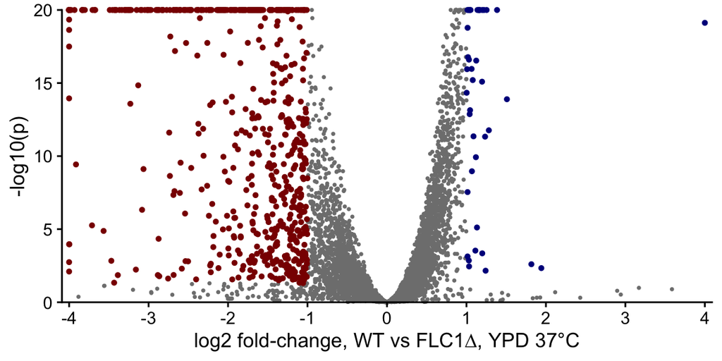

```r
volcano_WTvsdelta_37C_YPD <-
  ggplot(data = deseq_df_WTvsdelta_37C_YPD,
         aes(x = log2FC, y = -log10(padj)) ) +
  geom_point(size = 0.5, colour = "grey50") +
  geom_point(data = DEGdf_WT_up2x_FDR5,
             size = 1, colour = "darkblue") +
  geom_point(data = DEGdf_WT_down2x_FDR5,
             size = 1, colour = "darkred") +
  scale_y_continuous("-log10(p)",
                     limits = c(0,20), expand = c(0,0),
                     oob=scales::squish) +
  scale_x_continuous("log2 fold-change, WT vs FLC1∆, YPD 37°C",
                     breaks = -5:5,
                     limits = c(-4,4), expand = c(0.01,0.01),
                     oob = scales::squish) +
  coord_cartesian(clip = "off")
volcano_WTvsdelta_37C_YPD
```

The volcano plot shows extensive differential gene expression, with more genes substantially down in WT (i.e. up in FLC1∆).

## Write outputs to files

```r
deseq_df_WTvsdelta_37C_YPD %>%
  dplyr::mutate(
    across(c(baseMean, log2FC, stderror), round, digits = 3)
  ) %>%
  dplyr::mutate(padj = signif(padj, digits = 4)) %>%
  write_tsv(file = here::here("results", "DEGs",
                              "deseq_df_WTvsdelta_37C_YPD.txt"))
```

```r
DEGdf_WT_up2x_FDR5 %>%
  dplyr::pull(gene) %>%
  write_lines(file = here::here("results", "DEGs",
                            "deglist_WTvsdelta_37C_YPD_up2x_FDR5.txt"))

DEGdf_WT_down2x_FDR5 %>%
  dplyr::pull(gene) %>%
  write_lines(file = here::here("results", "DEGs",
                            "deglist_WTvsdelta_37C_YPD_down2x_FDR5.txt"))
```

# Session Info

Package versions, etc., that ran this file.